# DADA2_template

Kate Bowie

11/14/2019

## Update: code re-run and updated 10/07/2020

Updated the silva taxonomic database to 138. Updated paths from putting this all on box. Updated reverse and foward trimming from 0 to 20.

## Purpose:

This template serves as a starting point for processing 16S rRNA gene sequencing data with DADA2. This template should be used to keep track of how the 16S rRNA gene sequencing data was processed.

To get started, make a copy of this template.

## Load workspace from DADA2_setup

Next, load the workspace `XXX_DADA2_setup.RData` that was created by running `DADA2_setup.Rmd`.

```r
# define workspace name
DADA2_setup_workspace <- "623_DADA2_setup.RData"
# load the workspace
load(DADA2_setup_workspace)

# source our list Functions
source("DADA2_Functions.R")
```

## Trims and filter the forward and reverse reads.

Input your decided upon parameters for trimming and filtering the raw .fastq files for each sample in your sequencing run. You will know which parameters to choose after careful inspection of the `DADA2_setup.html` knitted output, which contains graphs showing the quality profile of the forward and reverse reads for a subset of samples.

```r
forward_trim <- 20
reverse_trim <- 20
forward_trunc <- 240
reverse_trunc <- 230

filtered_F_R_reads_list <- filter(read_path,write_path,fnFs, fnRs, sample.names, forward_trim, reverse_trim, forward_trunc, reverse_trunc)

filtFs <- filtered_F_R_reads_list$forw
filtRs <- filtered_F_R_reads_list$rev
```

## Determine the error rates in our reads using our error DADA2 wrapper function

```r
# invoke our error function
errorlist <- error(filtFs, filtRs)
```

```
## 236109720 total bases in 1073226 reads from 4 samples will be used for learning the error rates.
```

```
## 221723670 total bases in 1055827 reads from 4 samples will be used for learning the error rates.
```

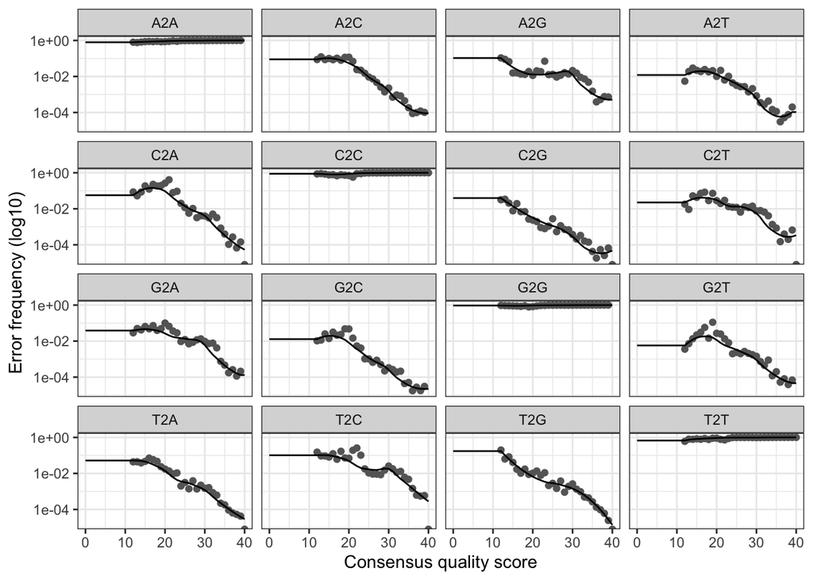

```r
# extract the estimated errors for the forward and reverse reads
errF <- errorlist$forw
errR <- errorlist$rev

# plot inline here
plotErrors(errF)
```

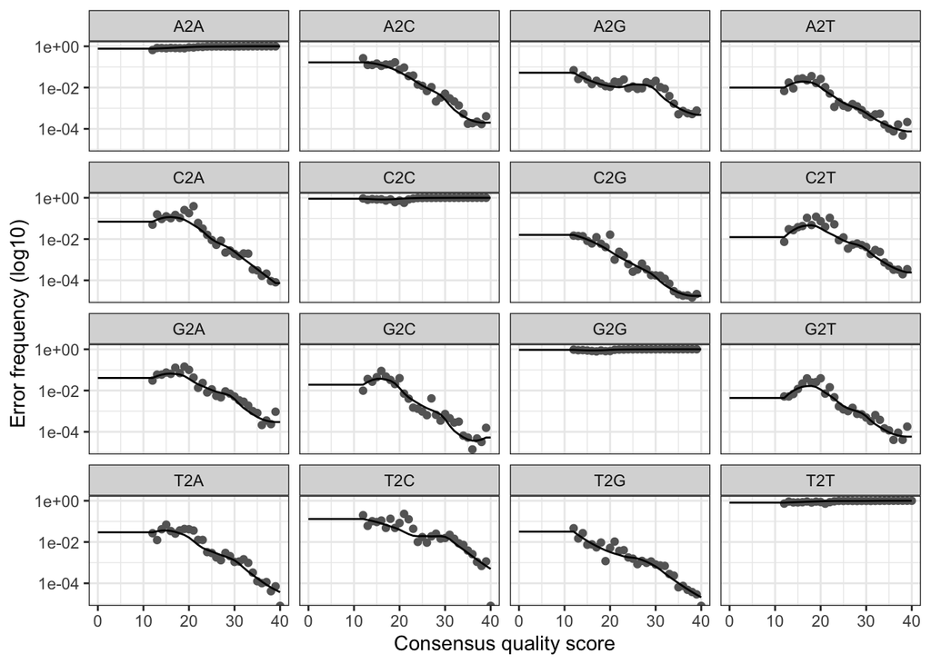

```r
plotErrors(errR)
```

# combine all identical sequences into unique sequences

```r
dereplist <- dereplicate(filtFs, filtRs,sample.names)
```

```
## Dereplicating sequence entries in Fastq file: /Users/bowiek/Box/Kate/MiSeq_Run_623/MiSeqRun_623_11_07_2019/Processed/filtered/s001_F_filt.fastq.gz
```

```
## Encountered 44054 unique sequences from 274982 total sequences read.
```

```
## Dereplicating sequence entries in Fastq file: /Users/bowiek/Box/Kate/MiSeq_Run_623/MiSeqRun_623_11_07_2019/Processed/filtered/s002_F_filt.fastq.gz
```

```
## Encountered 45314 unique sequences from 333971 total sequences read.
```

```
## Dereplicating sequence entries in Fastq file: /Users/bowiek/Box/Kate/MiSeq_Run_623/MiSeqRun_623_11_07_2019/Processed/filtered/s003_F_filt.fastq.gz
```

```
## Encountered 43697 unique sequences from 303230 total sequences read.
```

```
## Dereplicating sequence entries in Fastq file: /Users/bowiek/Box/Kate/MiSeq_Run_623/MiSeqRun_623_11_07_2019/Processed/filtered/s004_F_filt.fastq.gz
```

```
## Encountered 44305 unique sequences from 257645 total sequences read.
```

```
## Dereplicating sequence entries in Fastq file: /Users/bowiek/Box/Kate/MiSeq_Run_623/MiSeqRun_623_11_07_2019/Processed/filtered/s005_F_filt.fastq.gz
```

```
## Encountered 46003 unique sequences from 349517 total sequences read.
```

```
## Dereplicating sequence entries in Fastq file: /Users/bowiek/Box/Kate/MiSeq_Run_623/MiSeqRun_623_11_07_2019/Processed/filtered/s006_F_filt.fastq.gz
```

```
## Encountered 49297 unique sequences from 375968 total sequences read.
```

```
## Dereplicating sequence entries in Fastq file: /Users/bowiek/Box/Kate/MiSeq_Run_623/MiSeqRun_623_11_07_2019/Processed/filtered/s007_F_filt.fastq.gz
```

```
## Encountered 46154 unique sequences from 309619 total sequences read.
```

```
## Dereplicating sequence entries in Fastq file: /Users/bowiek/Box/Kate/MiSeq_Run_623/MiSeqRun_623_11_07_2019/Processed/filtered/s008_F_filt.fastq.gz
```

```
## Encountered 43041 unique sequences from 329572 total sequences read.
```

```
## Dereplicating sequence entries in Fastq file: /Users/bowiek/Box/Kate/MiSeq_Run_623/MiSeqRun_623_11_07_2019/Processed/filtered/s009_F_filt.fastq.gz
```

```
## Encountered 42634 unique sequences from 261817 total sequences read.
```

```
## Dereplicating sequence entries in Fastq file: /Users/bowiek/Box/Kate/MiSeq_Run_623/MiSeqRun_623_11_07_2019/Processed/filtered/s010_F_filt.fastq.gz
```

```
## Encountered 38290 unique sequences from 262969 total sequences read.
```

```
## Dereplicating sequence entries in Fastq file: /Users/bowiek/Box/Kate/MiSeq_Run_623/MiSeqRun_623_11_07_2019/Processed/filtered/s011_F_filt.fastq.gz
```

```
## Encountered 43571 unique sequences from 301899 total sequences read.
```

```
## Dereplicating sequence entries in Fastq file: /Users/bowiek/Box/Kate/MiSeq_Run_623/MiSeqRun_623_11_07_2019/Processed/filtered/s012_F_filt.fastq.gz
```

```
## Encountered 28051 unique sequences from 222226 total sequences read.
```

```
## Dereplicating sequence entries in Fastq file: /Users/bowiek/Box/Kate/MiSeq_Run_623/MiSeqRun_623_11_07_2019/Processed/filtered/s013_F_filt.fastq.gz
```

```
## Encountered 32969 unique sequences from 258125 total sequences read.
```

```
## Dereplicating sequence entries in Fastq file: /Users/bowiek/Box/Kate/MiSeq_Run_623/MiSeqRun_623_11_07_2019/Processed/filtered/s014_F_filt.fastq.gz
```

```
## Encountered 32945 unique sequences from 251311 total sequences read.
```

```
## Dereplicating sequence entries in Fastq file: /Users/bowiek/Box/Kate/MiSeq_Run_623/MiSeqRun_623_11_07_2019/Processed/filtered/s015_F_filt.fastq.gz
```

```
## Encountered 41079 unique sequences from 269645 total sequences read.
```

```
## Dereplicating sequence entries in Fastq file: /Users/bowiek/Box/Kate/MiSeq_Run_623/MiSeqRun_623_11_07_2019/Processed/filtered/s016_F_filt.fastq.gz
```

```
## Encountered 29694 unique sequences from 201182 total sequences read.
```

```
## Dereplicating sequence entries in Fastq file: /Users/bowiek/Box/Kate/MiSeq_Run_623/MiSeqRun_623_11_07_2019/Processed/filtered/s017_F_filt.fastq.gz
```

```
## Encountered 57582 unique sequences from 363522 total sequences read.
```

```
## Dereplicating sequence entries in Fastq file: /Users/bowiek/Box/Kate/MiSeq_Run_623/MiSeqRun_623_11_07_2019/Processed/filtered/s018_F_filt.fastq.gz
```

```
## Encountered 36624 unique sequences from 293561 total sequences read.
```

```
## Dereplicating sequence entries in Fastq file: /Users/bowiek/Box/Kate/MiSeq_Run_623/MiSeqRun_623_11_07_2019/Processed/filtered/s019_F_filt.fastq.gz
```

```
## Encountered 44266 unique sequences from 235444 total sequences read.
```

```
## Dereplicating sequence entries in Fastq file: /Users/bowiek/Box/Kate/MiSeq_Run_623/MiSeqRun_623_11_07_2019/Processed/filtered/s020_F_filt.fastq.gz
```

```
## Encountered 36961 unique sequences from 253118 total sequences read.
```

```
## Dereplicating sequence entries in Fastq file: /Users/bowiek/Box/Kate/MiSeq_Run_623/MiSeqRun_623_11_07_2019/Processed/filtered/s021_F_filt.fastq.gz
```

```
## Encountered 28388 unique sequences from 219158 total sequences read.
```

```
## Dereplicating sequence entries in Fastq file: /Users/bowiek/Box/Kate/MiSeq_Run_623/MiSeqRun_623_11_07_2019/Processed/filtered/s022_F_filt.fastq.gz
```

```
## Encountered 92479 unique sequences from 304964 total sequences read.
```

```
## Dereplicating sequence entries in Fastq file: /Users/bowiek/Box/Kate/MiSeq_Run_623/MiSeqRun_623_11_07_2019/Processed/filtered/s023_F_filt.fastq.gz
```

```
## Encountered 95964 unique sequences from 353556 total sequences read.
```

```
## Dereplicating sequence entries in Fastq file: /Users/bowiek/Box/Kate/MiSeq_Run_623/MiSeqRun_623_11_07_2019/Processed/filtered/s024_F_filt.fastq.gz
```

```
## Encountered 83470 unique sequences from 308891 total sequences read.
```

```
## Dereplicating sequence entries in Fastq file: /Users/bowiek/Box/Kate/MiSeq_Run_623/MiSeqRun_623_11_07_2019/Processed/filtered/s025_F_filt.fastq.gz
```

```
## Encountered 90741 unique sequences from 324016 total sequences read.
```

```
## Dereplicating sequence entries in Fastq file: /Users/bowiek/Box/Kate/MiSeq_Run_623/MiSeqRun_623_11_07_2019/Processed/filtered/s026_F_filt.fastq.gz
```

```
## Encountered 74360 unique sequences from 264550 total sequences read.
```

```
## Dereplicating sequence entries in Fastq file: /Users/bowiek/Box/Kate/MiSeq_Run_623/MiSeqRun_623_11_07_2019/Processed/filtered/s027_F_filt.fastq.gz
```

```
## Encountered 92768 unique sequences from 322389 total sequences read.
```

```
## Dereplicating sequence entries in Fastq file: /Users/bowiek/Box/Kate/MiSeq_Run_623/MiSeqRun_623_11_07_2019/Processed/filtered/s028_F_filt.fastq.gz
```

```
## Encountered 83326 unique sequences from 334605 total sequences read.
```

```
## Dereplicating sequence entries in Fastq file: /Users/bowiek/Box/Kate/MiSeq_Run_623/MiSeqRun_623_11_07_2019/Processed/filtered/s029_F_filt.fastq.gz
```

```
## Encountered 66177 unique sequences from 300500 total sequences read.
```

```
## Dereplicating sequence entries in Fastq file: /Users/bowiek/Box/Kate/MiSeq_Run_623/MiSeqRun_623_11_07_2019/Processed/filtered/s030_F_filt.fastq.gz
```

```
## Encountered 42632 unique sequences from 219351 total sequences read.
```

```
## Dereplicating sequence entries in Fastq file: /Users/bowiek/Box/Kate/MiSeq_Run_623/MiSeqRun_623_11_07_2019/Processed/filtered/s001_R_filt.fastq.gz
```

```
## Encountered 54547 unique sequences from 274982 total sequences read.
```

```
## Dereplicating sequence entries in Fastq file: /Users/bowiek/Box/Kate/MiSeq_Run_623/MiSeqRun_623_11_07_2019/Processed/filtered/s002_R_filt.fastq.gz
```

```
## Encountered 62547 unique sequences from 333971 total sequences read.
```

```
## Dereplicating sequence entries in Fastq file: /Users/bowiek/Box/Kate/MiSeq_Run_623/MiSeqRun_623_11_07_2019/Processed/filtered/s003_R_filt.fastq.gz
```

```
## Encountered 56834 unique sequences from 303230 total sequences read.
```

```
## Dereplicating sequence entries in Fastq file: /Users/bowiek/Box/Kate/MiSeq_Run_623/MiSeqRun_623_11_07_2019/Processed/filtered/s004_R_filt.fastq.gz
```

```
## Encountered 54221 unique sequences from 257645 total sequences read.
```

```
## Dereplicating sequence entries in Fastq file: /Users/bowiek/Box/Kate/MiSeq_Run_623/MiSeqRun_623_11_07_2019/Processed/filtered/s005_R_filt.fastq.gz
```

```
## Encountered 64800 unique sequences from 349517 total sequences read.
```

```
## Dereplicating sequence entries in Fastq file: /Users/bowiek/Box/Kate/MiSeq_Run_623/MiSeqRun_623_11_07_2019/Processed/filtered/s006_R_filt.fastq.gz
```

```
## Encountered 68566 unique sequences from 375968 total sequences read.
```

```
## Dereplicating sequence entries in Fastq file: /Users/bowiek/Box/Kate/MiSeq_Run_623/MiSeqRun_623_11_07_2019/Processed/filtered/s007_R_filt.fastq.gz
```

```
## Encountered 62205 unique sequences from 309619 total sequences read.
```

```
## Dereplicating sequence entries in Fastq file: /Users/bowiek/Box/Kate/MiSeq_Run_623/MiSeqRun_623_11_07_2019/Processed/filtered/s008_R_filt.fastq.gz
```

```
## Encountered 60090 unique sequences from 329572 total sequences read.
```

```
## Dereplicating sequence entries in Fastq file: /Users/bowiek/Box/Kate/MiSeq_Run_623/MiSeqRun_623_11_07_2019/Processed/filtered/s009_R_filt.fastq.gz
```

```
## Encountered 55814 unique sequences from 261817 total sequences read.
```

```
## Dereplicating sequence entries in Fastq file: /Users/bowiek/Box/Kate/MiSeq_Run_623/MiSeqRun_623_11_07_2019/Processed/filtered/s010_R_filt.fastq.gz
```

```
## Encountered 52916 unique sequences from 262969 total sequences read.
```

```
## Dereplicating sequence entries in Fastq file: /Users/bowiek/Box/Kate/MiSeq_Run_623/MiSeqRun_623_11_07_2019/Processed/filtered/s011_R_filt.fastq.gz
```

```
## Encountered 59442 unique sequences from 301899 total sequences read.
```

```
## Dereplicating sequence entries in Fastq file: /Users/bowiek/Box/Kate/MiSeq_Run_623/MiSeqRun_623_11_07_2019/Processed/filtered/s012_R_filt.fastq.gz
```

```
## Encountered 39139 unique sequences from 222226 total sequences read.
```

```
## Dereplicating sequence entries in Fastq file: /Users/bowiek/Box/Kate/MiSeq_Run_623/MiSeqRun_623_11_07_2019/Processed/filtered/s013_R_filt.fastq.gz
```

```
## Encountered 45841 unique sequences from 258125 total sequences read.
```

```
## Dereplicating sequence entries in Fastq file: /Users/bowiek/Box/Kate/MiSeq_Run_623/MiSeqRun_623_11_07_2019/Processed/filtered/s014_R_filt.fastq.gz
```

```
## Encountered 45731 unique sequences from 251311 total sequences read.
```

```
## Dereplicating sequence entries in Fastq file: /Users/bowiek/Box/Kate/MiSeq_Run_623/MiSeqRun_623_11_07_2019/Processed/filtered/s015_R_filt.fastq.gz
```

```
## Encountered 51925 unique sequences from 269645 total sequences read.
```

```
## Dereplicating sequence entries in Fastq file: /Users/bowiek/Box/Kate/MiSeq_Run_623/MiSeqRun_623_11_07_2019/Processed/filtered/s016_R_filt.fastq.gz
```

```
## Encountered 39152 unique sequences from 201182 total sequences read.
```

```
## Dereplicating sequence entries in Fastq file: /Users/bowiek/Box/Kate/MiSeq_Run_623/MiSeqRun_623_11_07_2019/Processed/filtered/s017_R_filt.fastq.gz
```

```
## Encountered 73149 unique sequences from 363522 total sequences read.
```

```
## Dereplicating sequence entries in Fastq file: /Users/bowiek/Box/Kate/MiSeq_Run_623/MiSeqRun_623_11_07_2019/Processed/filtered/s018_R_filt.fastq.gz
```

```
## Encountered 52235 unique sequences from 293561 total sequences read.
```

```
## Dereplicating sequence entries in Fastq file: /Users/bowiek/Box/Kate/MiSeq_Run_623/MiSeqRun_623_11_07_2019/Processed/filtered/s019_R_filt.fastq.gz
```

```
## Encountered 53921 unique sequences from 235444 total sequences read.
```

```
## Dereplicating sequence entries in Fastq file: /Users/bowiek/Box/Kate/MiSeq_Run_623/MiSeqRun_623_11_07_2019/Processed/filtered/s020_R_filt.fastq.gz
```

```
## Encountered 51859 unique sequences from 253118 total sequences read.
```

```
## Dereplicating sequence entries in Fastq file: /Users/bowiek/Box/Kate/MiSeq_Run_623/MiSeqRun_623_11_07_2019/Processed/filtered/s021_R_filt.fastq.gz
```

```
## Encountered 41046 unique sequences from 219158 total sequences read.
```

```
## Dereplicating sequence entries in Fastq file: /Users/bowiek/Box/Kate/MiSeq_Run_623/MiSeqRun_623_11_07_2019/Processed/filtered/s022_R_filt.fastq.gz
```

```
## Encountered 85315 unique sequences from 304964 total sequences read.
```

```
## Dereplicating sequence entries in Fastq file: /Users/bowiek/Box/Kate/MiSeq_Run_623/MiSeqRun_623_11_07_2019/Processed/filtered/s023_R_filt.fastq.gz
```

```
## Encountered 91199 unique sequences from 353556 total sequences read.
```

```
## Dereplicating sequence entries in Fastq file: /Users/bowiek/Box/Kate/MiSeq_Run_623/MiSeqRun_623_11_07_2019/Processed/filtered/s024_R_filt.fastq.gz
```

```
## Encountered 78826 unique sequences from 308891 total sequences read.
```

```
## Dereplicating sequence entries in Fastq file: /Users/bowiek/Box/Kate/MiSeq_Run_623/MiSeqRun_623_11_07_2019/Processed/filtered/s025_R_filt.fastq.gz
```

```
## Encountered 85979 unique sequences from 324016 total sequences read.
```

```
## Dereplicating sequence entries in Fastq file: /Users/bowiek/Box/Kate/MiSeq_Run_623/MiSeqRun_623_11_07_2019/Processed/filtered/s026_R_filt.fastq.gz
```

```
## Encountered 75381 unique sequences from 264550 total sequences read.
```

```
## Dereplicating sequence entries in Fastq file: /Users/bowiek/Box/Kate/MiSeq_Run_623/MiSeqRun_623_11_07_2019/Processed/filtered/s027_R_filt.fastq.gz
```

```
## Encountered 92200 unique sequences from 322389 total sequences read.
```

```
## Dereplicating sequence entries in Fastq file: /Users/bowiek/Box/Kate/MiSeq_Run_623/MiSeqRun_623_11_07_2019/Processed/filtered/s028_R_filt.fastq.gz
```

```
## Encountered 82444 unique sequences from 334605 total sequences read.
```

```
## Dereplicating sequence entries in Fastq file: /Users/bowiek/Box/Kate/MiSeq_Run_623/MiSeqRun_623_11_07_2019/Processed/filtered/s029_R_filt.fastq.gz
```

```
## Encountered 57632 unique sequences from 300500 total sequences read.
```

```
## Dereplicating sequence entries in Fastq file: /Users/bowiek/Box/Kate/MiSeq_Run_623/MiSeqRun_623_11_07_2019/Processed/filtered/s030_R_filt.fastq.gz
```

```
## Encountered 46818 unique sequences from 219351 total sequences read.
```

```r
derepFs <- dereplist$forw
derepRs <- dereplist$rev

rm(dereplist)
```

## Invoke our sample inference DADA2 wrapper

```r
samplelist <- sampleinf(derepFs, derepRs,errF,errR)
```

```
## Sample 1 - 274982 reads in 44054 unique sequences.
## Sample 2 - 333971 reads in 45314 unique sequences.
## Sample 3 - 303230 reads in 43697 unique sequences.
## Sample 4 - 257645 reads in 44305 unique sequences.
## Sample 5 - 349517 reads in 46003 unique sequences.
## Sample 6 - 375968 reads in 49297 unique sequences.
## Sample 7 - 309619 reads in 46154 unique sequences.
## Sample 8 - 329572 reads in 43041 unique sequences.
## Sample 9 - 261817 reads in 42634 unique sequences.
## Sample 10 - 262969 reads in 38290 unique sequences.
## Sample 11 - 301899 reads in 43571 unique sequences.
## Sample 12 - 222226 reads in 28051 unique sequences.
## Sample 13 - 258125 reads in 32969 unique sequences.
## Sample 14 - 251311 reads in 32945 unique sequences.
## Sample 15 - 269645 reads in 41079 unique sequences.
## Sample 16 - 201182 reads in 29694 unique sequences.
## Sample 17 - 363522 reads in 57582 unique sequences.
## Sample 18 - 293561 reads in 36624 unique sequences.
## Sample 19 - 235444 reads in 44266 unique sequences.
## Sample 20 - 253118 reads in 36961 unique sequences.
## Sample 21 - 219158 reads in 28388 unique sequences.
## Sample 22 - 304964 reads in 92479 unique sequences.
## Sample 23 - 353556 reads in 95964 unique sequences.
## Sample 24 - 308891 reads in 83470 unique sequences.
## Sample 25 - 324016 reads in 90741 unique sequences.
## Sample 26 - 264550 reads in 74360 unique sequences.
## Sample 27 - 322389 reads in 92768 unique sequences.
## Sample 28 - 334605 reads in 83326 unique sequences.
## Sample 29 - 300500 reads in 66177 unique sequences.
## Sample 30 - 219351 reads in 42632 unique sequences.
## Sample 1 - 274982 reads in 54547 unique sequences.
## Sample 2 - 333971 reads in 62547 unique sequences.
## Sample 3 - 303230 reads in 56834 unique sequences.
## Sample 4 - 257645 reads in 54221 unique sequences.
## Sample 5 - 349517 reads in 64800 unique sequences.
## Sample 6 - 375968 reads in 68566 unique sequences.
## Sample 7 - 309619 reads in 62205 unique sequences.
## Sample 8 - 329572 reads in 60090 unique sequences.
## Sample 9 - 261817 reads in 55814 unique sequences.
## Sample 10 - 262969 reads in 52916 unique sequences.
## Sample 11 - 301899 reads in 59442 unique sequences.
## Sample 12 - 222226 reads in 39139 unique sequences.
## Sample 13 - 258125 reads in 45841 unique sequences.
## Sample 14 - 251311 reads in 45731 unique sequences.
## Sample 15 - 269645 reads in 51925 unique sequences.
## Sample 16 - 201182 reads in 39152 unique sequences.
## Sample 17 - 363522 reads in 73149 unique sequences.
## Sample 18 - 293561 reads in 52235 unique sequences.
## Sample 19 - 235444 reads in 53921 unique sequences.
## Sample 20 - 253118 reads in 51859 unique sequences.
## Sample 21 - 219158 reads in 41046 unique sequences.
## Sample 22 - 304964 reads in 85315 unique sequences.
## Sample 23 - 353556 reads in 91199 unique sequences.
## Sample 24 - 308891 reads in 78826 unique sequences.
## Sample 25 - 324016 reads in 85979 unique sequences.
## Sample 26 - 264550 reads in 75381 unique sequences.
## Sample 27 - 322389 reads in 92200 unique sequences.
## Sample 28 - 334605 reads in 82444 unique sequences.
## Sample 29 - 300500 reads in 57632 unique sequences.
## Sample 30 - 219351 reads in 46818 unique sequences.
```

```r
dadaFs <- samplelist$forw
dadaRs <- samplelist$rev

rm(samplelist)
```

## Merge the forward and reverse reads together to obtain the full denoised sequences.

```r
# invoke the `mergePairs` function
mergers <- mergePairs(dadaFs, derepFs, dadaRs, derepRs, verbose=TRUE)
```

```
## 272987 paired-reads (in 289 unique pairings) successfully merged out of 274468 (in 521 pairings) input.
```

```
## 329105 paired-reads (in 203 unique pairings) successfully merged out of 333354 (in 562 pairings) input.
```

```
## 300521 paired-reads (in 258 unique pairings) successfully merged out of 302866 (in 507 pairings) input.
```

```
## 253050 paired-reads (in 305 unique pairings) successfully merged out of 257226 (in 638 pairings) input.
```

```
## 347071 paired-reads (in 237 unique pairings) successfully merged out of 349050 (in 600 pairings) input.
```

```
## 369216 paired-reads (in 234 unique pairings) successfully merged out of 375402 (in 715 pairings) input.
```

```
## 307003 paired-reads (in 134 unique pairings) successfully merged out of 309265 (in 521 pairings) input.
```

```
## 326461 paired-reads (in 292 unique pairings) successfully merged out of 329044 (in 590 pairings) input.
```

```
## 256211 paired-reads (in 216 unique pairings) successfully merged out of 260944 (in 468 pairings) input.
```

```
## 260949 paired-reads (in 169 unique pairings) successfully merged out of 262575 (in 338 pairings) input.
```

```
## 295052 paired-reads (in 171 unique pairings) successfully merged out of 301407 (in 487 pairings) input.
```

```
## 220877 paired-reads (in 180 unique pairings) successfully merged out of 221958 (in 268 pairings) input.
```

```
## 254507 paired-reads (in 167 unique pairings) successfully merged out of 257623 (in 382 pairings) input.
```

```
## 249095 paired-reads (in 124 unique pairings) successfully merged out of 250630 (in 272 pairings) input.
```

```
## 268144 paired-reads (in 245 unique pairings) successfully merged out of 269324 (in 424 pairings) input.
```

```
## 197646 paired-reads (in 144 unique pairings) successfully merged out of 200221 (in 301 pairings) input.
```

```
## 360625 paired-reads (in 288 unique pairings) successfully merged out of 363013 (in 565 pairings) input.
```

```
## 288329 paired-reads (in 140 unique pairings) successfully merged out of 293137 (in 406 pairings) input.
```

```
## 232621 paired-reads (in 242 unique pairings) successfully merged out of 234910 (in 524 pairings) input.
```

```
## 247512 paired-reads (in 174 unique pairings) successfully merged out of 252641 (in 442 pairings) input.
```

```
## 215640 paired-reads (in 90 unique pairings) successfully merged out of 218205 (in 198 pairings) input.
```

```
## 266299 paired-reads (in 427 unique pairings) successfully merged out of 303369 (in 4972 pairings) input.
```

```
## 314453 paired-reads (in 420 unique pairings) successfully merged out of 352202 (in 4624 pairings) input.
```

```
## 280713 paired-reads (in 363 unique pairings) successfully merged out of 307667 (in 3768 pairings) input.
```

```
## 287527 paired-reads (in 377 unique pairings) successfully merged out of 322596 (in 4024 pairings) input.
```

```
## 239985 paired-reads (in 310 unique pairings) successfully merged out of 263182 (in 3045 pairings) input.
```

```
## 286219 paired-reads (in 397 unique pairings) successfully merged out of 320796 (in 4438 pairings) input.
```

```
## 301442 paired-reads (in 362 unique pairings) successfully merged out of 333362 (in 3391 pairings) input.
```

```
## 277822 paired-reads (in 373 unique pairings) successfully merged out of 299419 (in 2330 pairings) input.
```

```
## 211913 paired-reads (in 96 unique pairings) successfully merged out of 218945 (in 320 pairings) input.
```

```r
# Inspect the merger data.frame from the first sample
head(mergers[[1]])
```

```
##                                                                                                                                                                                                                       sequence
## 1 CTCGGAATTACTGGGCGTAAAGCGTGCGTAGGTGGTCGTTTAAGTCCGTTGTGAAAGCCC…
## 2 TCCGGAATTATTGGGCGTAAAGCGCGCGTAGGCGGTTTTTTAAGTCTGATGTGAAAGCCC…
## 3 ATCGGAATTACTGGGCGTAAAGCGCACGCAGGCGGTTTGTTAAGTCAGATGTGAAATCCC…
## 4 ATCGGAATTACTGGGCGTAAAGCGCGCGTAGGTGGTTCGTTAAGTTGGATGTGAAAGCCC…
## 5 TCCGGAATTATTGGGCGTAAAGGGCTCGCAGGCGGTTCCTTAAGTCTGATGTGAAAGCCC…
## 6 ATCGGAATTACTGGGCGTAAAGCGCACGCAGGCGGTCTGTCAAGTCGGATGTGAAATCCC…
##   abundance forward reverse nmatch nmismatch nindel prefer accept
## 1    214242       1       1    210         0      0      1   TRUE
## 2      5485       3       3    210         0      0      1   TRUE
## 3      5482       2       2    210         0      0      1   TRUE
## 4      4656       4       4    210         0      0      1   TRUE
## 5      4059       6       5    210         0      0      2   TRUE
## 6      3600       5       6    210         0      0      1   TRUE
```

## Construct the asv sequence table.

```r
seqtab <- makeSequenceTable(mergers)
## The sequences being tabled vary in length.
dim(seqtab)
```

```
## [1]   30 2820
```

```r
# Inspect distribution of sequence lengths
table(nchar(getSequences(seqtab)))
```

```
##
##  220  234  243  247  249  261  263  267  281  290  301  302  317  378  381  383
## 1826    1    1    4    1    1   96    3    1    1  850   18    1    4    1    9
##  385
##    2
```

## Remove any chimeras present.

```r
seqtab.nochim <- removeChim(seqtab)
```

```
## Identified 1197 bimeras out of 2820 input sequences.
```

## Track what reads made it through filtering.

```r
track <- trackuniq(filtered_F_R_reads_list$cut,dadaFs, dadaRs, mergers, seqtab.nochim, sample.names)

track
```

```
##       input filtered denoisedF denoisedR merged nonchim
## s001 297278   274982    274635    274749 272987  269396
## s002 359784   333971    333431    333813 329105  326838
## s003 326510   303230    302918    303089 300521  297431
## s004 279774   257645    257366    257425 253050  249207
## s005 376149   349517    349212    349272 347071  345508
## s006 403689   375968    375599    375660 369216  367339
## s007 333640   309619    309380    309430 307003  306363
## s008 352818   329572    329238    329299 326461  321904
## s009 285424   261817    261256    261465 256211  254311
## s010 283548   262969    262782    262696 260949  259519
## s011 326544   301899    301507    301724 295052  294316
## s012 234585   222226    222011    222117 220877  219422
## s013 275484   258125    257748    257961 254507  253840
## s014 266719   251311    250734    251148 249095  249049
## s015 290584   269645    269427    269494 268144  263908
## s016 216087   201182    200780    200548 197646  197165
## s017 396356   363522    363161    363241 360625  355326
## s018 314197   293561    293279    293368 288329  288037
## s019 256282   235444    234993    235298 232621  228870
## s020 272499   253118    252911    252804 247512  246866
## s021 230723   219158    218289    219051 215640  215640
## s022 338900   304964    304010    304106 266299  179394
## s023 394962   353556    352695    352836 314453  225769
## s024 346570   308891    308174    308219 280713  212027
## s025 365153   324016    323199    323235 287527  212174
## s026 297999   264550    263712    263903 239985  187242
## s027 362325   322389    321519    321405 286219  200241
## s028 370205   334605    333817    333963 301442  230128
## s029 325119   300500    299925    299839 277822  212760
## s030 233206   219351    219171    219041 211913  211246
```

# quick save workspace to troubleshoot

```r
save.image("Dada2_workspace_mid.RData")
```

## Assign taxonomy.

```r
taxalist <- assigntax(seqtab.nochim, taxpath, species_path)
taxa.print <- taxalist$print
taxa <- taxalist$ob
```

## Make mapping file sample names agree with seqtab.nochim

NOTE: Sometimes the sampleName variable in the metadata file is not consistent with the naming of the sequencing files, i.e., “s001” vs “s1” NOTE: SOLUTION is to standardize naming to be the same between Miseq sequencing sample sheet and our metadata files

```r
#map_file <-read.delim(file = map, sep = '\t',header = TRUE)
# inspect the seqtab.nochim rownames to see if there are any discrpencies between mapping file
#rownames(seqtab.nochim) -> xxxx
# replace the rownames with the correct format so the phyloseq object can be constructed with no errors
#rownames(seqtab.nochim) <- map_file[,1]
```

## Create Phyloseq Object.

NOTE: the `Miseq_run_name` and the `mapping_file_path` arguments for the `constructphylo` function are subject to change.

```r
ps <- constructphylo(seqtab.nochim, taxa, MiseqRun, map)

# look at ps
ps
```

```
## phyloseq-class experiment-level object
## otu_table()   OTU Table:         [ 1623 taxa and 30 samples ]
## sample_data() Sample Data:       [ 30 samples by 11 sample variables ]
## tax_table()   Taxonomy Table:    [ 1623 taxa by 7 taxonomic ranks ]
```

## Save the R workspace containing all the read data and intermediate steps.

```r
save.image(file.path(write_path,paste(MiseqRun,"_DADA2_Processing.RData",sep="")))
```

# Clean up workspace and remove all environment variables but the phyloseq object.

```r
x <- ls()
x <- x[!x %in% c('ps','write_path','MiseqRun')]
rm(list = x)
rm(x)

# Save limited workspace
save.image(file.path(write_path,paste(MiseqRun,"_Dada2_phyloseq.RData",sep = "")))

#### End of sequence processing ####
```